# Final Project

Kelsey Gonzalez and Laura Werthmann

Due Dec 11, 2019

Load packages

```r
library(tidyverse)    # data manipulation and visualization
library(kernlab)      # SVM methodology
library(e1071)        # SVM methodology
library(ISLR)         # contains example data set "Khan"
library(RColorBrewer) # customized coloring of plots
library(performanceEstimation) # for performance estimation of svm
library(RCurl) # for performance estimation of svm
library(factoextra) #for hopkins statistic
library(clustertend) #for hopkins statistic
library(cluster) # for gower similarity, pam, and diana (a divisive hierarchical method). clara() is also included, which is basically pam by sampling
library(Rtsne) # for t-SNE plot
library(ggrepel)
library(dbscan)
library(rpart)
library(rpart.plot)
library(DMwR2)
library(rsample)
library(adabag)
library(ipred)
library(randomForest)
library(gbm)
library(performanceEstimation)
library(e1071)
library(nnet)
options(scipen = 999)
```

# Data Preprocessing

Review of World Health Organization’s Life Expectancy Data taken from [Kaggle](https://www.kaggle.com/kumarajarshi/life-expectancy-who).

```r
rm(list=ls())
load("LifeExpectancyData.Rdata")
data$Status = as.factor(data$Status)
data = subset(data,select = -c(`Hepatitis B`))
```

Then we aquire data to include continent values

```r
# from https://github.com/lukes/ISO-3166-Countries-with-Regional-Codes
ISO3166 <- read.csv(text = (getURL("https://raw.githubusercontent.com/lukes/ISO-3166-Countries-with-Regional-Codes/master/all/all.csv")))
ISO3166$name <- as.character(ISO3166$name)
# They use Eswatini instead of Swaziland, so let's update that & other naming mismatches
ISO3166$name[ISO3166$name == "Moldova, Republic of"] <- "Republic of Moldova"
ISO3166$name[ISO3166$name == "Korea, Republic of"] <- "Republic of Korea"
ISO3166$name[ISO3166$name == "Korea (Democratic People's Republic of)"] <- "Democratic People's Republic of Korea"
ISO3166$name[ISO3166$name == "Congo, Democratic Republic of the"] <- "Democratic Republic of the Congo"
ISO3166$name[ISO3166$name == "North Macedonia"] <- "The former Yugoslav republic of Macedonia"
ISO3166$name[ISO3166$name == "Tanzania, United Republic of"] <- "United Republic of Tanzania"
```

We created a country data frame to make the data join more easily, and then joined them by country(“country”, “name”), while adding the continent (“region”)

```r
countries <- as.data.frame(unique(data$Country))
colnames(countries) <- "Country"
countries$Country <- as.character(countries$Country)

dfcountry <- left_join(x = countries,
                   y = ISO3166,
                   by = c("Country" = "name"))


data <- left_join(x = data,
                   y = dfcountry[,c("Country","region")],
                   by = c("Country" = "Country"))
```

```r
data$Life <- data$`Life expectancy`
data$Status = as.factor(data$Status)
data$Country = as.factor(data$Country)

data <- data %>% select(-c(Polio, "percentage expenditure", Measles, `HIV/AIDS`))

data2013 <- data %>% filter(Year=="2013") %>% drop_na()
```

# Describe Data set

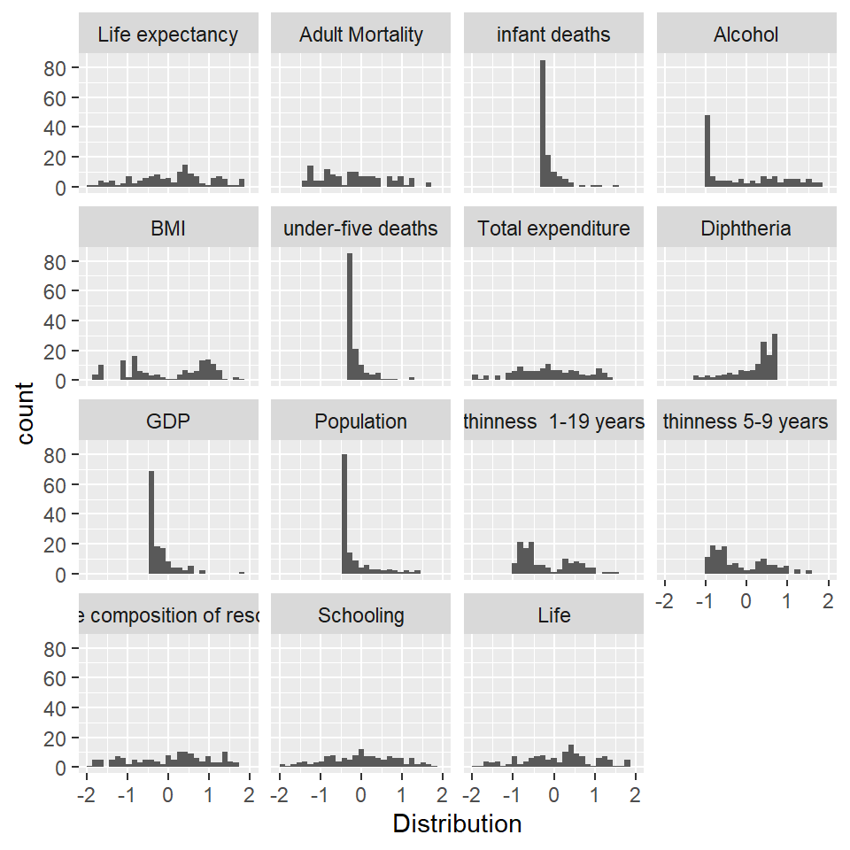

looks like we need to log: infant deaths alcohol under-fives deaths GDP Population

```r
data2013 <- data2013 %>% mutate(log_infant_deaths = log(`infant deaths`+1) ,
                                log_alcohol = log(Alcohol),
                                log_under_five = log(`under-five deaths`+1) ,
                                log_GDP = log(GDP),
                                log_Population = log(Population)) %>%
  select(-c(`infant deaths`,
            Alcohol,
            `under-five deaths`,
            GDP,
            Population))
```

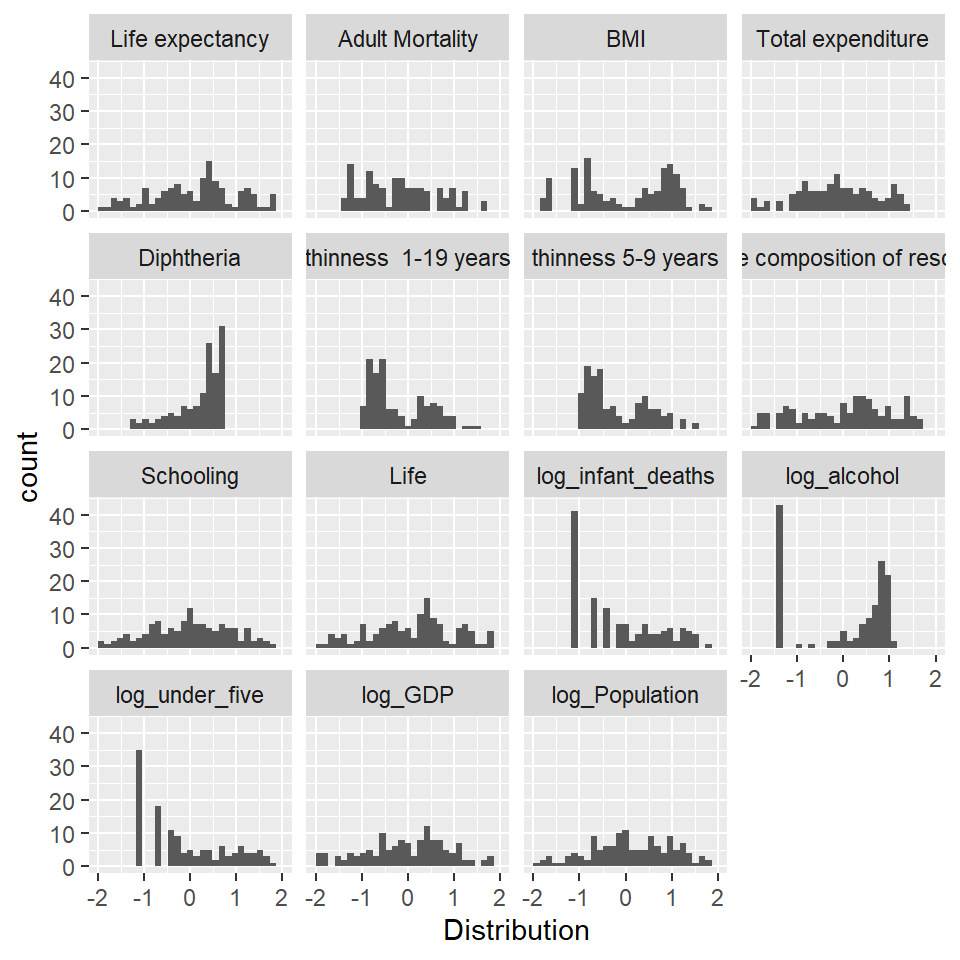

```r
set.seed(5)

ten_countries <- data2013 %>%
  select(Country) %>%
  sample_n(.,10)
```

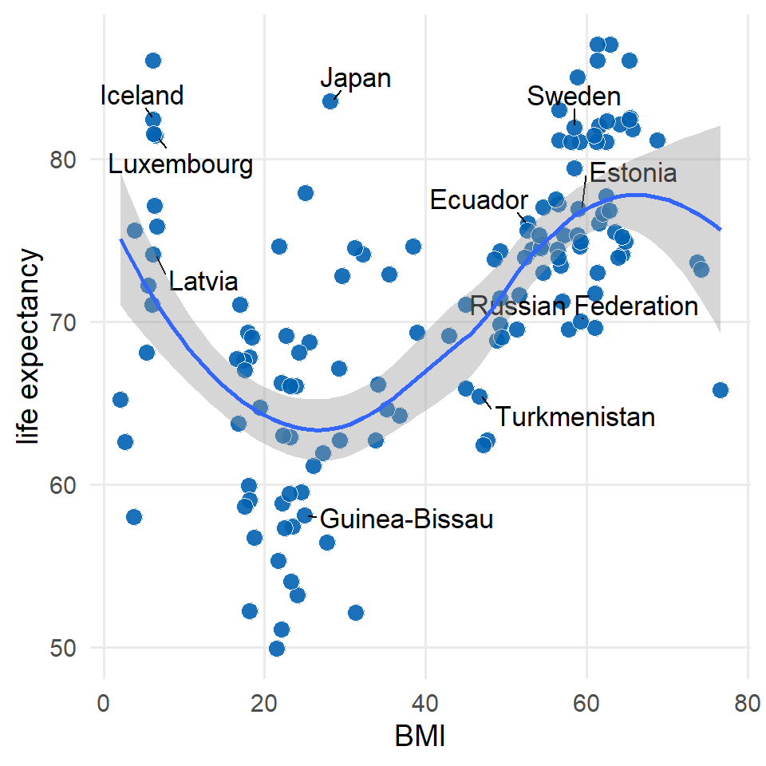

```r
data2013 %>%
  mutate(label = ifelse(Country %in% ten_countries$Country,
                        as.character(Country),
                        "")) %>%
  ggplot(aes(BMI, `Life expectancy`)) +
  geom_point(size = 3.5,
             alpha = .9,
             shape = 21,
             col = "white",
             fill = "#0162B2") +
  geom_text_repel(aes(label = label),
                  size = 4.5,
                  point.padding = .2,
                  box.padding = .3,
                  force = 1,
                  min.segment.length = 0) +
  theme_minimal(14) +
  theme(legend.position = "none",
        panel.grid.minor = element_blank()) +
  labs(x = "BMI",
       y = "life expectancy") +
  geom_smooth()
```

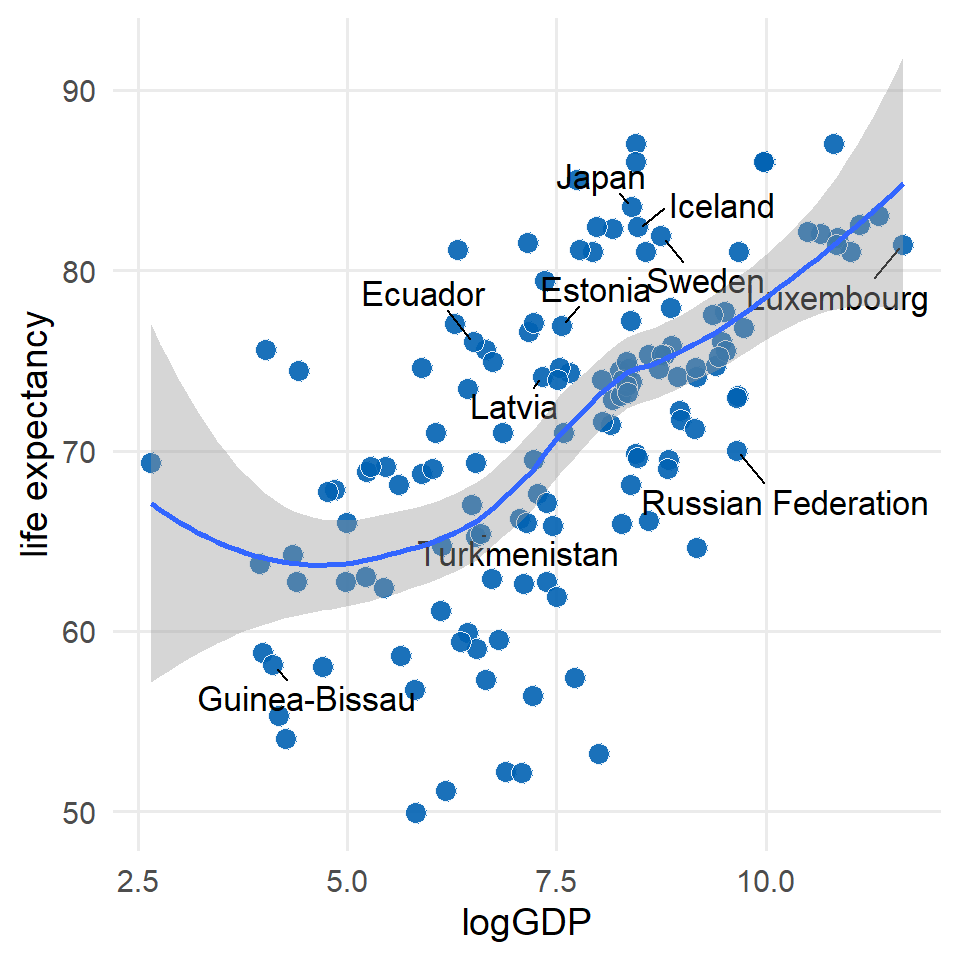

```r
data2013 %>%
  mutate(label = ifelse(Country %in% ten_countries$Country,
                        as.character(Country),
                        "")) %>%
  ggplot(aes(log_GDP, `Life expectancy`)) +
  geom_point(size = 3.5,
             alpha = .9,
             shape = 21,
             col = "white",
             fill = "#0162B2") +
  geom_text_repel(aes(label = label),
                  size = 4.5,
                  point.padding = .2,
                  box.padding = .3,
                  force = 1,
                  min.segment.length = 0) +
  theme_minimal(14) +
  theme(legend.position = "none",
        panel.grid.minor = element_blank()) +
  labs(x = "logGDP",
       y = "life expectancy")+
  geom_smooth()
```

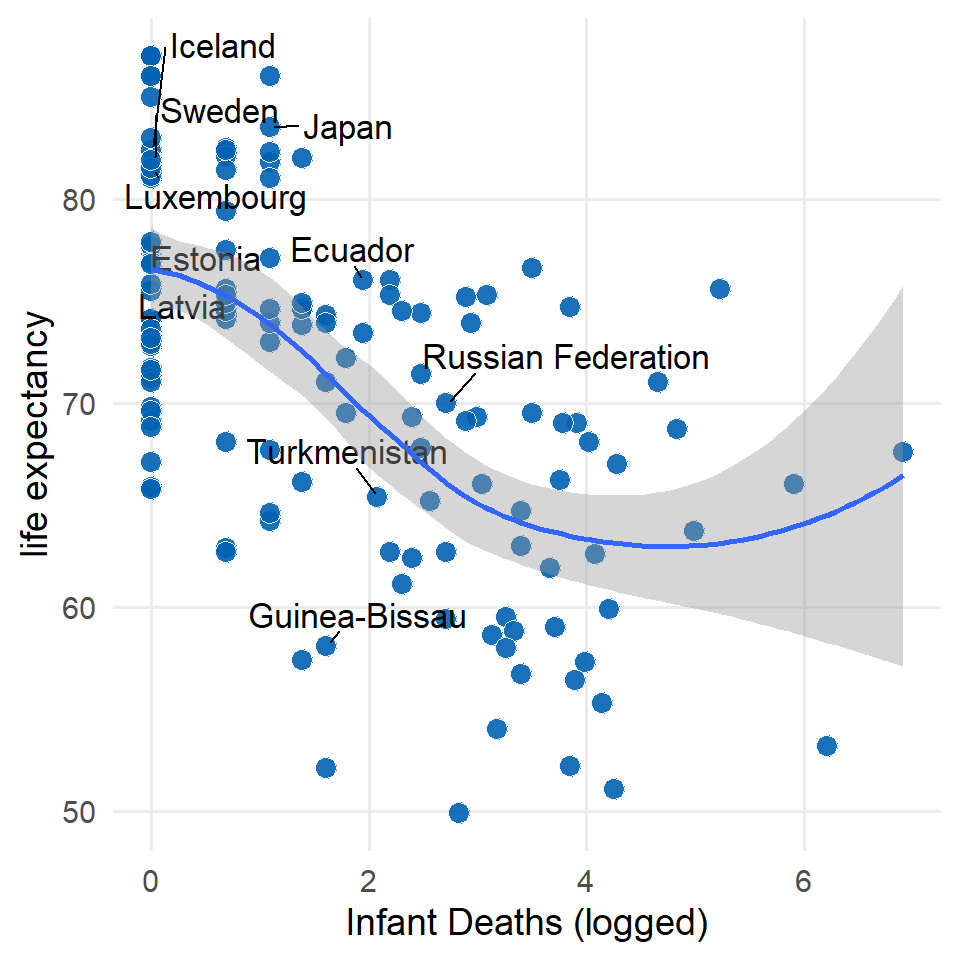

```r
data2013 %>%
  mutate(label = ifelse(Country %in% ten_countries$Country,
                        as.character(Country),
                        "")) %>%
  ggplot(aes(log_infant_deaths, `Life expectancy`)) +
  geom_point(size = 3.5,
             alpha = .9,
             shape = 21,
             col = "white",
             fill = "#0162B2") +
  geom_text_repel(aes(label = label),
                  size = 4.5,
                  point.padding = .2,
                  box.padding = .3,
                  force = 1,
                  min.segment.length = 0) +
  theme_minimal(14) +
  theme(legend.position = "none",
        panel.grid.minor = element_blank()) +
  labs(x = "Infant Deaths (logged)",
       y = "life expectancy")+
  geom_smooth()
```

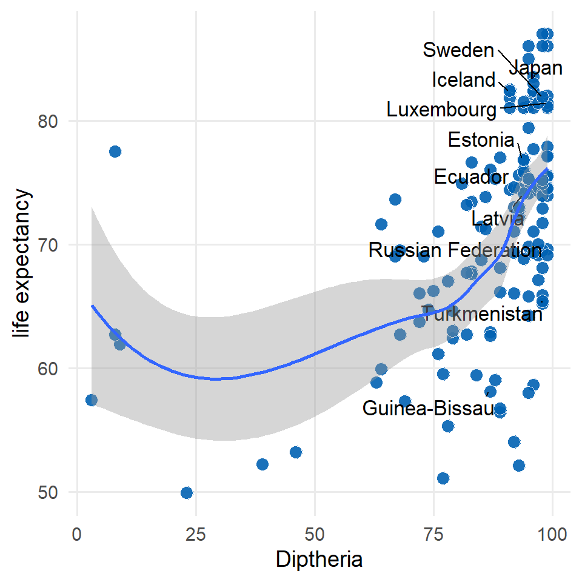

```r
data2013 %>%
  mutate(label = ifelse(Country %in% ten_countries$Country,
                        as.character(Country),
                        "")) %>%
  ggplot(aes(Diphtheria, `Life expectancy`)) +
  geom_point(size = 3.5,
             alpha = .9,
             shape = 21,
             col = "white",
             fill = "#0162B2") +
  geom_text_repel(aes(label = label),
                  size = 4.5,
                  point.padding = .2,
                  box.padding = .3,
                  force = 1,
                  min.segment.length = 0) +
  theme_minimal(14) +
  theme(legend.position = "none",
        panel.grid.minor = element_blank()) +
  labs(x = "Diptheria",
       y = "life expectancy")+
  geom_smooth()
```

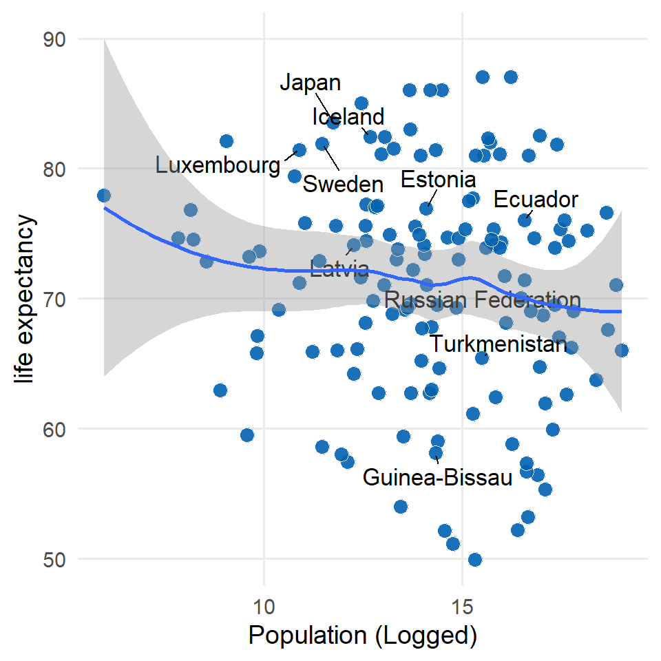

```r
data2013 %>%
  mutate(label = ifelse(Country %in% ten_countries$Country,
                        as.character(Country),
                        "")) %>%
  ggplot(aes(log_Population, `Life expectancy`)) +
  geom_point(size = 3.5,
             alpha = .9,
             shape = 21,
             col = "white",
             fill = "#0162B2") +
  geom_text_repel(aes(label = label),
                  size = 4.5,
                  point.padding = .2,
                  box.padding = .3,
                  force = 1,
                  min.segment.length = 0) +
  theme_minimal(14) +
  theme(legend.position = "none",
        panel.grid.minor = element_blank()) +
  labs(x = "Population (Logged)",
       y = "life expectancy")+
  geom_smooth()
```

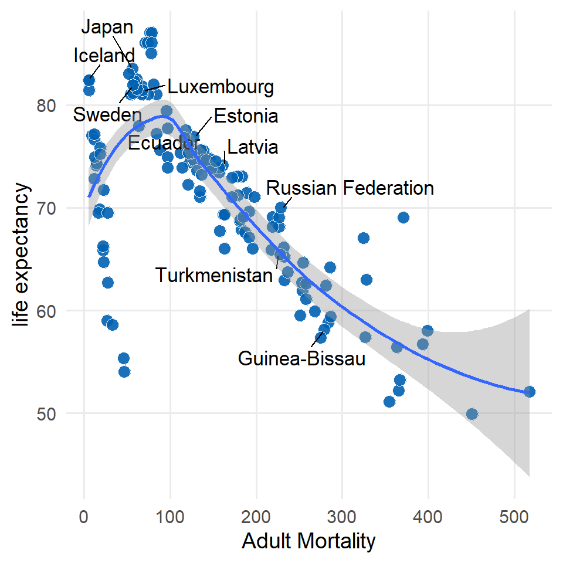

```r
data2013 %>%
  mutate(label = ifelse(Country %in% ten_countries$Country,
                        as.character(Country),
                        "")) %>%
  ggplot(aes(`Adult Mortality`, `Life expectancy`)) +
  geom_point(size = 3.5,
             alpha = .9,
             shape = 21,
             col = "white",
             fill = "#0162B2") +
  geom_text_repel(aes(label = label),
                  size = 4.5,
                  point.padding = .2,
                  box.padding = .3,
                  force = 1,
                  min.segment.length = 0) +
  theme_minimal(14) +
  theme(legend.position = "none",
        panel.grid.minor = element_blank()) +
  labs(x = "Adult Mortality",
       y = "life expectancy")+
  geom_smooth()
```

# Descriptive Analyses

## Pam Clustering

First things first, do our data even have a natural clustering tendency? the larger the result, the higher clustering tendency

```r
# Hopkins, for numerical data only

data_no_cat <- data2013 %>%
  select(-Country, -Status, -region, -Year) %>%
  as.matrix()
rownames(data_no_cat) <- data2013$Country

res <- get_clust_tendency(data_no_cat, n=137, graph = TRUE)
res$hopkins_stat
```

```
## [1] 0.3022675
```

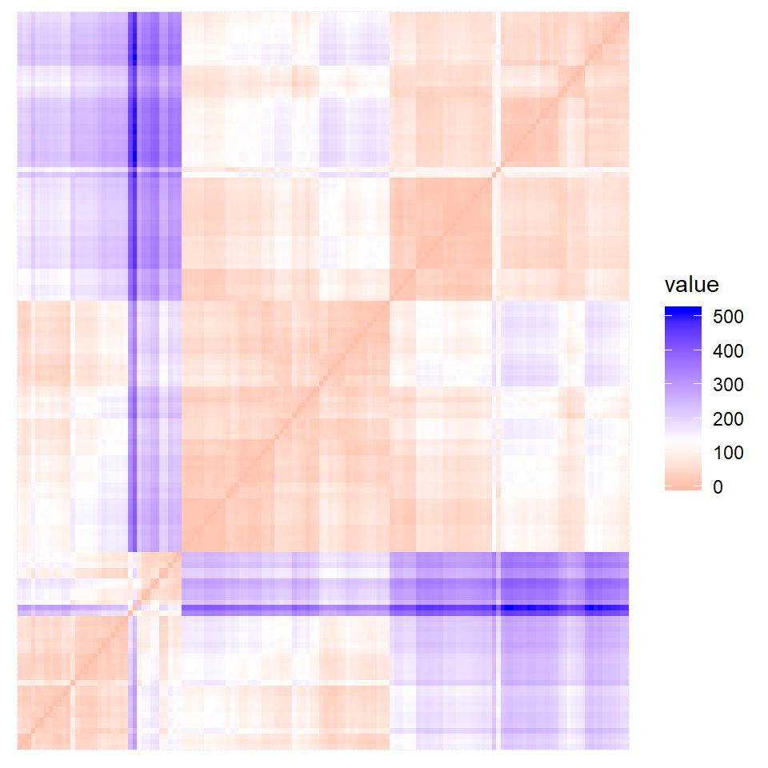

```r
res$plot
```

```r
df <- data[, -5]

random_df <- apply(df, 2,
                function(x){runif(length(2), min(1), (max(4)))})
random_df <- as.data.frame(random_df)
# Standardize the data sets

#df <- scale(df)
random_df <- scale(random_df)


res <- get_clust_tendency(random_df, n = nrow(random_df)-1,
                          graph = FALSE)
res$hopkins_stat
```

```
## [1] 0.6294823
```

```r
res$plot
```

```r
set.seed(78)
res <- hopkins(data_no_cat, n = 137)
res$H
```

```
## [1] 0.2624508
```

The same goes for the random dataframe

```r
resran <- get_clust_tendency(random_df, n = nrow(random_df)-1,
                          graph = FALSE)
res$hopkins_stat
```

```r
gower_dist <- daisy(data2013[, -1],
                    metric = "gower")


# Check attributes to ensure the correct methods are being used (I = interval, N = nominal)
# Note that despite logratio being called, the type remains coded as "I"

# cleaning it up
gower_mat <- as.matrix(gower_dist)
rownames(gower_mat) <- colnames(gower_mat) <- data2013$Country
```

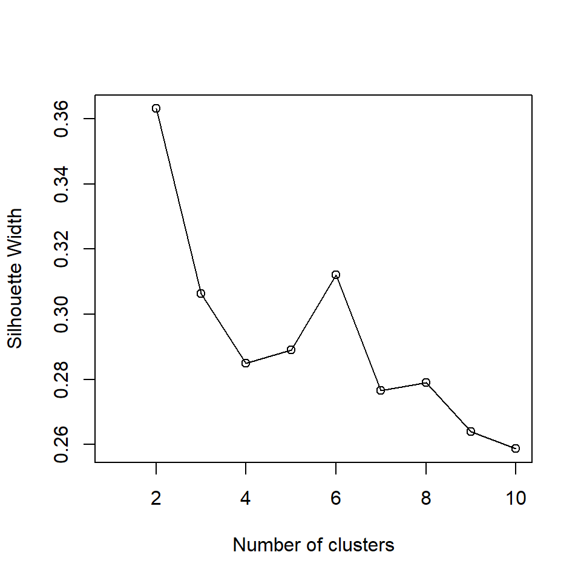

```r
sil <- c(NA)
for(i in 2:10){
  pam_fit <- pam(gower_mat, diss=TRUE, k=i)
  sil[i] <-pam_fit$silinfo$avg.width
}

plot(1:10, sil,
xlab = "Number of clusters",
ylab = "Silhouette Width",
lines(1:10, sil))
```

review 2 clusters

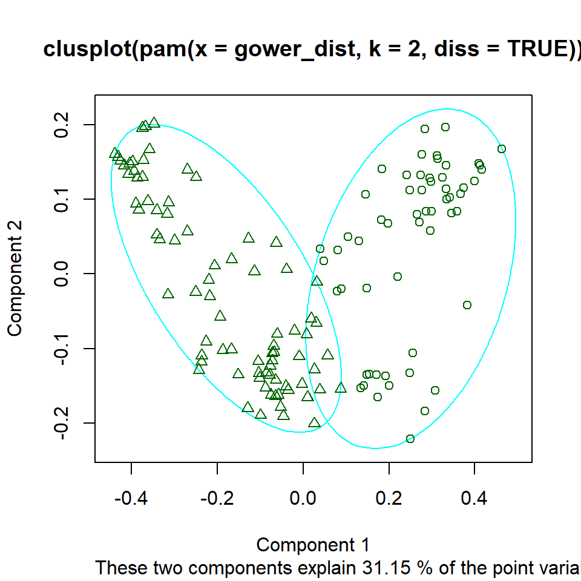

```r
pam_fit <- pam(gower_dist, diss = TRUE, k = 2)

# add cluster labels to the data. We will use result1 later
data_clean <- data.frame(data2013, pam_fit$cluster)

# show clustering results by country
result1 <- data_clean %>% select(Country,pam_fit.cluster)
clusplot(pam_fit)
```

Review 3 clusters

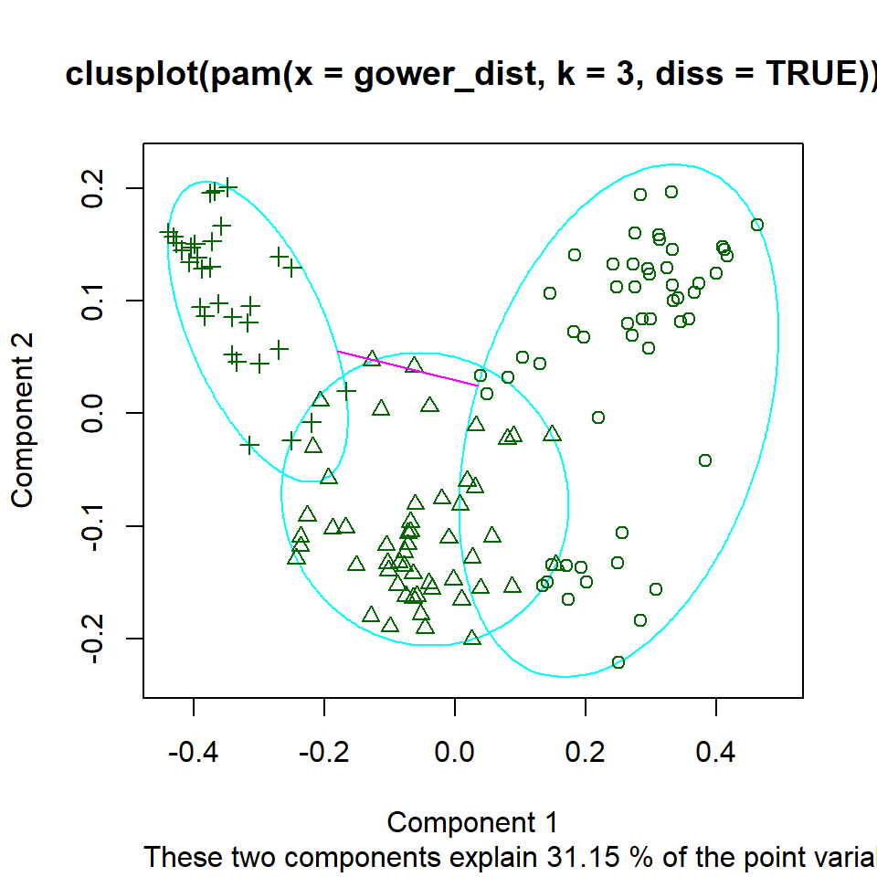

```r
pam_fit <- pam(gower_dist, diss = TRUE, k = 3)

# add cluster labels to the data. We will use result1 later
data_clean <- data.frame(data2013, pam_fit$cluster)

# show clustering results by country
result1 <- data_clean %>% select(Country,pam_fit.cluster)
clusplot(pam_fit)
```

group_by cluster and then compute the summary data (means, median, etc) for each cluster

```r
data_results <- data_clean %>%
  mutate(cluster = pam_fit.cluster) %>% #add the cluster column
  select(-pam_fit.cluster) %>%
  group_by(cluster) %>% #group countries by its cluster
  do(the_summary = summary(.)) #do: summarize by group/cluster,add the_summary column

data_results$the_summary
```

```
## [[1]]
##         Country        Year             Status   Life.expectancy
##  Afghanistan: 1   Min.   :2013   Developed : 0   Min.   :49.9
##  Angola     : 1   1st Qu.:2013   Developing:53   1st Qu.:58.6
##  Bangladesh : 1   Median :2013                   Median :63.0
##  Benin      : 1   Mean   :2013                   Mean   :62.9
##  Bhutan     : 1   3rd Qu.:2013                   3rd Qu.:67.7
##  Botswana   : 1   Max.   :2013                   Max.   :74.1
##  (Other)    :47
##  Adult.Mortality      BMI        Total.expenditure   Diphtheria
##  Min.   : 12.0   Min.   : 2.10   Min.   : 1.290    Min.   : 3.00
##  1st Qu.:163.0   1st Qu.:18.20   1st Qu.: 3.980    1st Qu.:73.00
##  Median :233.0   Median :23.20   Median : 5.190    Median :83.00
##  Mean   :224.8   Mean   :24.93   Mean   : 5.574    Mean   :77.17
##  3rd Qu.:286.0   3rd Qu.:29.40   3rd Qu.: 6.580    3rd Qu.:92.00
##  Max.   :518.0   Max.   :57.80   Max.   :11.700    Max.   :99.00
##
##  thinness..1.19.years thinness.5.9.years Income.composition.of.resources
##  Min.   : 1.000       Min.   : 1.200     Min.   :0.3410
##  1st Qu.: 5.700       1st Qu.: 5.900     1st Qu.:0.4640
##  Median : 7.000       Median : 6.900     Median :0.5080
##  Mean   : 7.953       Mean   : 7.772     Mean   :0.5262
##  3rd Qu.: 8.600       3rd Qu.: 8.500     3rd Qu.:0.5890
##  Max.   :26.800       Max.   :27.500     Max.   :0.7650
##
##    Schooling          region        Life      log_infant_deaths
##  Min.   : 5.30           : 0   Min.   :49.9   Min.   :0.000
##  1st Qu.: 9.10   Africa  :39   1st Qu.:58.6   1st Qu.:1.609
##  Median :10.40   Americas: 0   Median :63.0   Median :3.178
##  Mean   :10.39   Asia    :13   Mean   :62.9   Mean   :2.912
##  3rd Qu.:11.60   Europe  : 0   3rd Qu.:67.7   3rd Qu.:3.892
##  Max.   :14.70   Oceania : 1   Max.   :74.1   Max.   :6.909
##
##   log_alcohol      log_under_five     log_GDP      log_Population
##  Min.   :-4.6052   Min.   :0.000   Min.   :2.654   Min.   : 8.559
##  1st Qu.:-4.6052   1st Qu.:1.946   1st Qu.:5.286   1st Qu.:13.448
##  Median :-4.6052   Median :3.526   Median :6.496   Median :14.566
##  Mean   :-2.7225   Mean   :3.200   Mean   :6.362   Mean   :14.720
##  3rd Qu.:-0.3567   3rd Qu.:4.369   3rd Qu.:7.219   3rd Qu.:16.949
##  Max.   : 2.3721   Max.   :7.171   Max.   :9.661   Max.   :19.018
```

[output cut: 94 more lines]

```
##  Min.   :-4.605   Min.   :0.0000   Min.   : 6.318   Min.   :10.90
##  1st Qu.: 2.155   1st Qu.:0.0000   1st Qu.: 7.958   1st Qu.:13.00
##  Median : 2.275   Median :0.0000   Median : 8.746   Median :14.19
##  Mean   : 2.060   Mean   :0.4101   Mean   : 9.017   Mean   :14.25
##  3rd Qu.: 2.403   3rd Qu.:0.6931   3rd Qu.: 9.987   3rd Qu.:15.59
##  Max.   : 2.711   Max.   :1.3863   Max.   :11.642   Max.   :16.96
##
##     cluster
##  Min.   :3
##  1st Qu.:3
##  Median :3
##  Mean   :3
##  3rd Qu.:3
##  Max.   :3
##
```

The results suggest: